# LME Analysis of NUCs

Antoin Rodgers

18.05.2022

## L targets

### Analysis of L timing

- initial run, step() found: `l_t ~ pre_syls + gender + (1 | speaker) + (1 | nuc_str_syl)`
- intercepts only model, needs trimming: rfemoved residual sd > 3

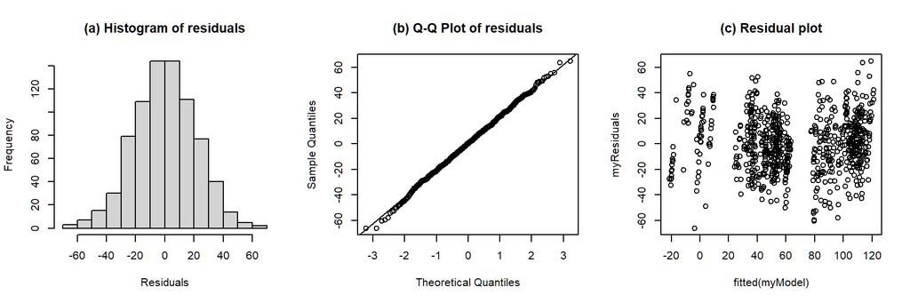

```
## Formula:  l_t ~ foot_syls + pre_syls + fin_phon + nuc_new_word + gender + (1 | speaker) + (1 | speech_rate) + (1 | nuc_str_syl)
##
## Linear mixed model fit by REML. t-tests use Satterthwaite's method [
## lmerModLmerTest]
## Formula: l_t_equation
##    Data: nuc_l_t_data.trimmed
## Control:
## lmerControl(optimizer = optimizer, calc.derivs = FALSE, optCtrl = list(method = "nlminb",
##     starttests = FALSE, kkt = FALSE))
##
## REML criterion at convergence: 7076.4
##
## Scaled residuals:
##      Min       1Q   Median       3Q      Max
## -2.99299 -0.64765  0.02657  0.62091  2.93147
##
## Random effects:
##  Groups      Name        Variance Std.Dev.
##  speech_rate (Intercept)  28.97    5.382
##  speaker     (Intercept) 132.77   11.523
##  nuc_str_syl (Intercept) 531.78   23.060
##  Residual                488.74   22.107
## Number of obs: 780, groups:  speech_rate, 632; speaker, 11; nuc_str_syl, 3
##
## Fixed effects:
##                  Estimate Std. Error       df t value Pr(>|t|)
## (Intercept)       91.8521    15.1488   3.2400   6.063  0.00719 **
## foot_syls2        -0.2311     4.2573 692.6314  -0.054  0.95673
## foot_syls3         1.1346     3.3255 711.9230   0.341  0.73307
## foot_syls4        -1.3484     5.3183 749.8215  -0.254  0.79993
## pre_syls1         -4.8149     3.3655 686.3357  -1.431  0.15297
## pre_syls2         -1.3164     5.3499 676.8053  -0.246  0.80570
## pre_syls3        -11.5519     5.5252 661.7005  -2.091  0.03693 *
## fin_phonL%         3.0806     5.1172 767.0533   0.602  0.54735
## nuc_new_wordTRUE  -3.2263     3.2491 751.9685  -0.993  0.32103
## genderM          -54.8771     7.1683   8.9560  -7.656 3.23e-05 ***
## ---
## Signif. codes:  0 '***' 0.001 '**' 0.01 '*' 0.05 '.' 0.1 ' ' 1
##
## Correlation of Fixed Effects:
```

[output cut: 24 more lines]

```
## Degrees of freedom method: Satterthwaite
##
##              Eliminated  Sum Sq Mean Sq NumDF  DenDF F value    Pr(>F)
## foot_syls             1   128.3    42.8     3 760.15  0.0826  0.969491
## fin_phon              2   243.2   243.2     1 770.00  0.4717  0.492421
## nuc_new_word          3   592.0   592.0     1 765.23  1.1485  0.284207
## pre_syls              0  7081.5  2360.5     3 761.67  4.5791  0.003465 **
## gender                0 31001.3 31001.3     1   8.99 60.1388 2.857e-05 ***
## ---
## Signif. codes:  0 '***' 0.001 '**' 0.01 '*' 0.05 '.' 0.1 ' ' 1
##
## Model found:
## l_t ~ pre_syls + gender + (1 | speaker) + (1 | nuc_str_syl)
##
## isSingular(my_model, tol = 1e-05 ) --> FALSE
```

Anova of model: l_t ~ foot_syls + pre_syls + fin_phon + nuc_new_word + gender + (1 | speaker) + (1 | speech_rate) + (1 | nuc_str_syl)

| term | sumsq | meansq | NumDF | DenDF | F value | p.value | signif. |
| --- | --- | --- | --- | --- | --- | --- | --- |
| foot_syls | 120.957 | 40.319 | 3 | 715.033 | 0.082 | 9.695591e-01 |  |
| pre_syls | 5882.372 | 1960.791 | 3 | 689.582 | 4.012 | 7.589526e-03 | p<0.01 |
| fin_phon | 177.125 | 177.125 | 1 | 767.053 | 0.362 | 5.473480e-01 |  |
| nuc_new_word | 481.920 | 481.920 | 1 | 751.968 | 0.986 | 3.210307e-01 |  |
| gender | 28644.005 | 28644.005 | 1 | 8.956 | 58.608 | 3.227658e-05 | p<0.001 |

[[1]]

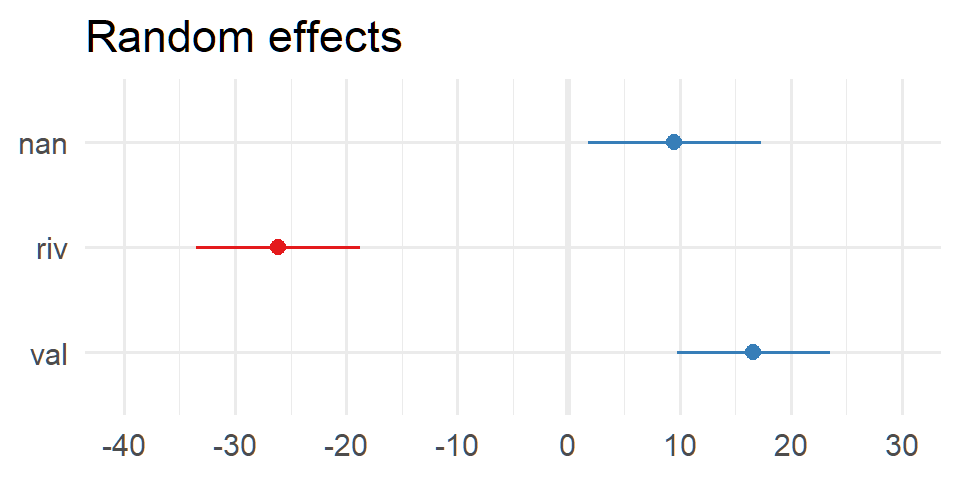

Conditional and marginal R<sup>2</sup> of model

| R2_conditional | R2_marginal |
| --- | --- |
| 0.75 | 0.39 |

$foot_syls

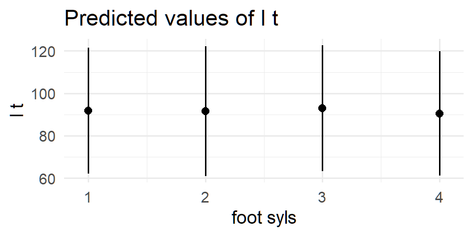

$pre_syls

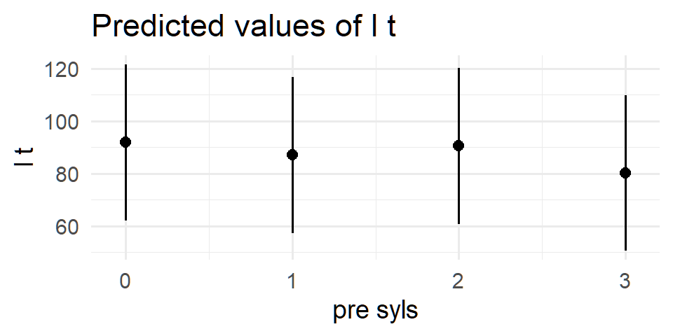

$fin_phon

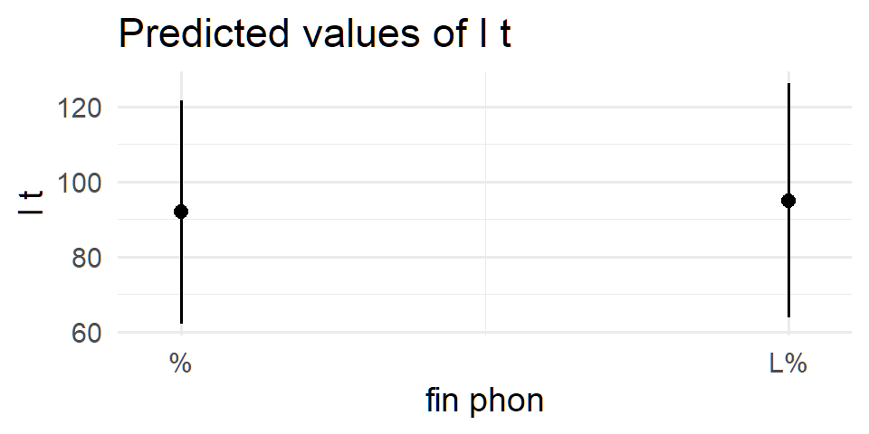

$nuc_new_word

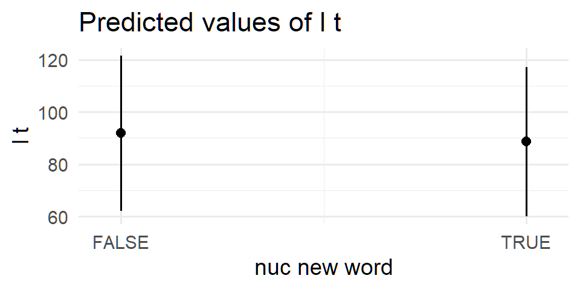

$gender

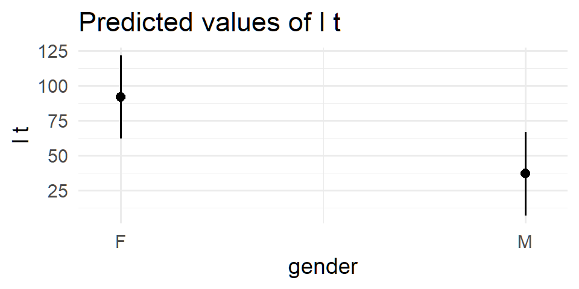

summary of model: l_t ~ foot_syls + pre_syls + fin_phon + nuc_new_word + gender + (1 | speaker) + (1 | speech_rate) + (1 | nuc_str_syl)

| term | estimate | conf.low | conf.high | std.error | t.value | df | p.value |
| --- | --- | --- | --- | --- | --- | --- | --- |
| (Intercept) | 91.852 | 45.600874 | 138.1033425 | 15.149 | 6.063 | 3.24 | 0.0072 |
| foot_syls2 | -0.231 | -8.589817 | 8.1276482 | 4.257 | -0.054 | 692.63 | 0.9567 |
| foot_syls3 | 1.135 | -5.394413 | 7.6636499 | 3.326 | 0.341 | 711.92 | 0.7331 |
| foot_syls4 | -1.348 | -11.788931 | 9.0921867 | 5.318 | -0.254 | 749.82 | 0.7999 |
| pre_syls1 | -4.815 | -11.422769 | 1.7928991 | 3.365 | -1.431 | 686.34 | 0.153 |
| pre_syls2 | -1.316 | -11.820789 | 9.1878958 | 5.350 | -0.246 | 676.81 | 0.8057 |
| pre_syls3 | -11.552 | -22.400879 | -0.7029748 | 5.525 | -2.091 | 661.70 | 0.0369 |
| fin_phonL% | 3.081 | -6.964847 | 13.1260658 | 5.117 | 0.602 | 767.05 | 0.5473 |
| nuc_new_wordTRUE | -3.226 | -9.604607 | 3.1519961 | 3.249 | -0.993 | 751.97 | 0.321 |
| genderM | -54.877 | -71.104969 | -38.6492045 | 7.168 | -7.656 | 8.96 | 3.2e-05 |

b0 for l_t ~ foot_syls + pre_syls + fin_phon + nuc_new_word + gender + (1 | speaker) + (1 | speech_rate) + (1 | nuc_str_syl)

| intercept | estimate | conf.low | conf.high | std.error | t.value | df | p.value |
| --- | --- | --- | --- | --- | --- | --- | --- |
| foot_syls1 | 91.8 | 45.6 | 138.1 | 15.15 | 6.06 | 3.24 | 0.007 |
| foot_syls2 | 91.6 | 46.6 | 136.7 | 15.59 | 5.88 | 3.63 | 0.006 |
| foot_syls3 | 93 | 46.7 | 139.3 | 15.14 | 6.14 | 3.24 | 0.007 |
| foot_syls4 | 90.5 | 43.7 | 137.3 | 14.98 | 6.04 | 3.10 | 0.008 |
| pre_syls0 | 91.8 | 45.6 | 138.1 | 15.15 | 6.06 | 3.24 | 0.007 |
| pre_syls1 | 87 | 40.9 | 133.2 | 15.17 | 5.74 | 3.26 | 0.008 |
| pre_syls2 | 90.5 | 44.3 | 136.8 | 15.15 | 5.98 | 3.24 | 0.007 |
| pre_syls3 | 80.3 | 34 | 126.6 | 15.11 | 5.31 | 3.21 | 0.011 |

b1 for l_t ~ foot_syls + pre_syls + fin_phon + nuc_new_word + gender + (1 | speaker) + (1 | speech_rate) + (1 | nuc_str_syl)

| intercept | slope | estimate | conf.low | conf.high | std.error | t.value | df | p.value |
| --- | --- | --- | --- | --- | --- | --- | --- | --- |
| foot_syls1 | foot_syls2 | -0.23 | -8.59 | 8.128 | 4.260 | -0.050 | 692.63 | 0.957 |
| foot_syls1 | foot_syls3 | 1.13 | -5.394 | 7.664 | 3.330 | 0.340 | 711.92 | 0.733 |
| foot_syls1 | foot_syls4 | -1.35 | -11.8 | 9.092 | 5.320 | -0.250 | 749.82 | 0.8 |
| foot_syls2 | foot_syls3 | 1.37 | -7.437 | 10.2 | 4.480 | 0.300 | 678.67 | 0.761 |
| foot_syls2 | foot_syls4 | -1.12 | -11.9 | 9.622 | 5.470 | -0.200 | 709.33 | 0.838 |
| foot_syls3 | foot_syls4 | -2.48 | -13.2 | 8.277 | 5.480 | -0.450 | 756.46 | 0.651 |
| pre_syls0 | pre_syls1 | -4.81 | -11.4 | 1.793 | 3.370 | -1.430 | 686.34 | 0.153 |
| pre_syls0 | pre_syls2 | -1.32 | -11.8 | 9.188 | 5.350 | -0.250 | 676.81 | 0.806 |
| pre_syls0 | pre_syls3 | -11.6 | -22.4 | -0.703 | 5.530 | -2.090 | 661.70 | 0.037 |
| pre_syls1 | pre_syls2 | 3.5 | -4.67 | 11.7 | 4.160 | 0.840 | 652.64 | 0.401 |
| pre_syls1 | pre_syls3 | -6.74 | -15.3 | 1.844 | 4.370 | -1.540 | 663.45 | 0.124 |
| pre_syls2 | pre_syls3 | -10.2 | -16.6 | -3.881 | 3.240 | -3.160 | 728.43 | 0.002 |
| intercept | fin_phonL% | 3.081 | -6.965 | 13.1 | 5.117 | 0.602 | 767.05 | 0.547 |
| intercept | nuc_new_wordTRUE | -3.226 | -9.605 | 3.152 | 3.249 | -0.993 | 751.97 | 0.321 |
| intercept | genderM | -54.9 | -71.1 | -38.6 | 7.168 | -7.656 | 8.96 | 3.2e-05 |

### Analysis of L F0

- Only intercepts only model avoided convergence and singularity issues
- step() suggests: `l_f0 ~ foot_syls + (1 | speaker) + (1 | nuc_pre_text)`
- but random intercepts only model words
- removed speech_rate and nuc_str_syl random effects to eliminate singularity in getModelFixedFX()
- model needs trimming (sd residuals > 3)

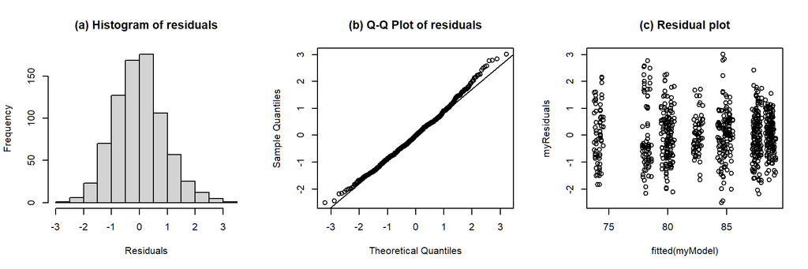

```
## Formula:  l_f0 ~ foot_syls + pre_syls + fin_phon + nuc_new_word + (1 | speaker) + (1 | speech_rate) + (1 | nuc_str_syl) + (1 | nuc_pre_text)
##
## Linear mixed model fit by REML. t-tests use Satterthwaite's method [
## lmerModLmerTest]
## Formula: l_f0_equation
##    Data: nuc_l_f0.trimmed
## Control:
## lmerControl(optimizer = optimizer, calc.derivs = FALSE, optCtrl = list(method = "nlminb",
##     starttests = FALSE, kkt = FALSE))
##
## REML criterion at convergence: 2179.6
##
## Scaled residuals:
##     Min      1Q  Median      3Q     Max
## -2.7162 -0.6919 -0.0252  0.5926  3.2633
##
## Random effects:
##  Groups       Name        Variance  Std.Dev.
##  speech_rate  (Intercept)  0.002498 0.04998
##  nuc_pre_text (Intercept)  0.020783 0.14416
##  speaker      (Intercept) 23.217751 4.81848
##  nuc_str_syl  (Intercept)  0.009043 0.09510
##  Residual                  0.850085 0.92200
## Number of obs: 778, groups:
## speech_rate, 629; nuc_pre_text, 12; speaker, 11; nuc_str_syl, 3
##
## Fixed effects:
##                   Estimate Std. Error        df t value Pr(>|t|)
## (Intercept)       82.88079    1.47922  10.70064  56.030 1.47e-14 ***
## foot_syls2         0.50972    0.26626   3.77984   1.914 0.132238
## foot_syls3         0.46453    0.13424 704.46998   3.460 0.000572 ***
## foot_syls4         0.81698    0.31460   4.51152   2.597 0.053497 .
## pre_syls1          0.12432    0.24474   2.69832   0.508 0.650047
## pre_syls2         -0.20615    0.33487   3.77175  -0.616 0.573339
## pre_syls3         -0.19722    0.33603   3.91251  -0.587 0.589458
## fin_phonL%        -0.03296    0.20952 757.73105  -0.157 0.875042
## nuc_new_wordTRUE   0.18961    0.16894   5.78329   1.122 0.306142
## ---
## Signif. codes:  0 '***' 0.001 '**' 0.01 '*' 0.05 '.' 0.1 ' ' 1
##
```

[output cut: 24 more lines]

```
## Backward reduced fixed-effect table:
## Degrees of freedom method: Satterthwaite
##
##              Eliminated  Sum Sq Mean Sq NumDF  DenDF F value  Pr(>F)
## fin_phon              1  0.0173  0.0173     1 759.11  0.0203 0.88682
## pre_syls              2  1.4632  0.4877     3   4.91  0.5728 0.65753
## nuc_new_word          3  3.1494  3.1494     1   8.55  3.6976 0.08837 .
## foot_syls             0 13.4482  4.4827     3  12.06  5.2637 0.01496 *
## ---
## Signif. codes:  0 '***' 0.001 '**' 0.01 '*' 0.05 '.' 0.1 ' ' 1
##
## Model found:
## l_f0 ~ foot_syls + (1 | speaker) + (1 | nuc_pre_text)
##
## isSingular(my_model, tol = 1e-05 ) --> FALSE
```

Anova of model: l_f0 ~ foot_syls + pre_syls + fin_phon + nuc_new_word + (1 | speaker) + (1 | speech_rate) + (1 | nuc_str_syl) + (1 | nuc_pre_text)

| term | sumsq | meansq | NumDF | DenDF | F value | p.value | signif. |
| --- | --- | --- | --- | --- | --- | --- | --- |
| foot_syls | 13.847 | 4.616 | 3 | 5.577 | 5.430 | 0.04240951 | p<0.05 |
| pre_syls | 2.144 | 0.715 | 3 | 4.077 | 0.841 | 0.53722787 |  |
| fin_phon | 0.021 | 0.021 | 1 | 757.731 | 0.025 | 0.87504229 |  |
| nuc_new_word | 1.071 | 1.071 | 1 | 5.783 | 1.260 | 0.30614209 |  |

Conditional and marginal R<sup>2</sup> of model

| R2_conditional | R2_marginal |
| --- | --- |
| 0.96 | 0 |

$foot_syls

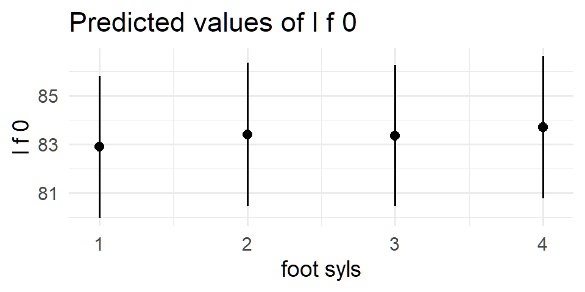

$pre_syls

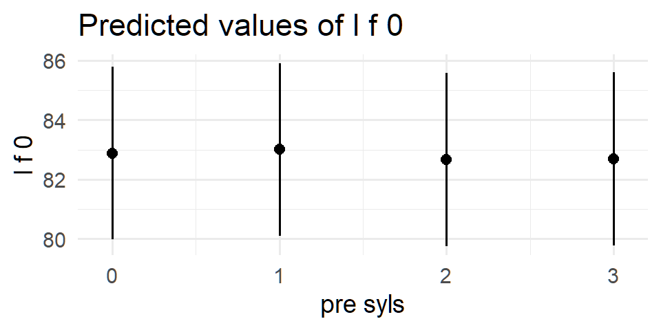

$fin_phon

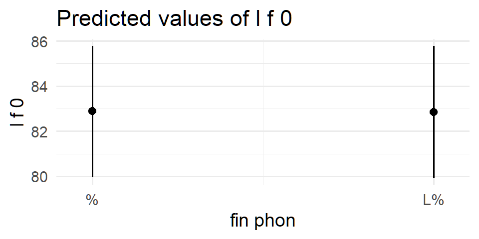

$nuc_new_word

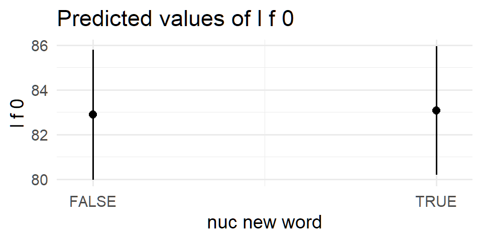

summary of model: l_f0 ~ foot_syls + pre_syls + fin_phon + nuc_new_word + (1 | speaker) + (1 | speech_rate) + (1 | nuc_str_syl) + (1 | nuc_pre_text)

| term | estimate | conf.low | conf.high | std.error | t.value | df | p.value |
| --- | --- | --- | --- | --- | --- | --- | --- |
| (Intercept) | 82.881 | 79.61389532 | 86.1476810 | 1.479 | 56.030 | 10.70 | 1.5e-14 |
| foot_syls2 | 0.510 | -0.24683374 | 1.2662693 | 0.266 | 1.914 | 3.78 | 0.1322 |
| foot_syls3 | 0.465 | 0.20097140 | 0.7280853 | 0.134 | 3.460 | 704.47 | 6e-04 |
| foot_syls4 | 0.817 | -0.01878952 | 1.6527557 | 0.315 | 2.597 | 4.51 | 0.0535 |
| pre_syls1 | 0.124 | -0.70619522 | 0.9548354 | 0.245 | 0.508 | 2.70 | 0.65 |
| pre_syls2 | -0.206 | -1.15850385 | 0.7462001 | 0.335 | -0.616 | 3.77 | 0.5733 |
| pre_syls3 | -0.197 | -1.13847438 | 0.7440372 | 0.336 | -0.587 | 3.91 | 0.5895 |
| fin_phonL% | -0.033 | -0.44427573 | 0.3783554 | 0.210 | -0.157 | 757.73 | 0.875 |
| nuc_new_wordTRUE | 0.190 | -0.22755665 | 0.6067703 | 0.169 | 1.122 | 5.78 | 0.3061 |

b0 for l_f0 ~ foot_syls + pre_syls + fin_phon + nuc_new_word + (1 | speaker) + (1 | speech_rate) + (1 | nuc_str_syl) + (1 | nuc_pre_text)

| intercept | estimate | conf.low | conf.high | std.error | t.value | df | p.value |
| --- | --- | --- | --- | --- | --- | --- | --- |
| foot_syls1 | 82.9 | 79.6 | 86.1 | 1.48 | 56.03 | 10.70 | 1.5e-14 |
| foot_syls2 | 83.4 | 80.1 | 86.7 | 1.50 | 55.58 | 11.26 | 4.2e-15 |
| foot_syls3 | 83.3 | 80.1 | 86.6 | 1.48 | 56.35 | 10.70 | 1.4e-14 |
| foot_syls4 | 83.7 | 80.4 | 87 | 1.49 | 56.25 | 10.93 | 8.2e-15 |
| pre_syls0 | 82.9 | 79.6 | 86.1 | 1.48 | 56.03 | 10.70 | 1.5e-14 |
| pre_syls1 | 83 | 79.7 | 86.3 | 1.48 | 56.10 | 10.71 | 1.4e-14 |
| pre_syls2 | 82.6 | 79.3 | 85.9 | 1.49 | 55.48 | 10.98 | 8.4e-15 |
| pre_syls3 | 82.7 | 79.4 | 86 | 1.49 | 55.59 | 10.92 | 9.4e-15 |

b1 for l_f0 ~ foot_syls + pre_syls + fin_phon + nuc_new_word + (1 | speaker) + (1 | speech_rate) + (1 | nuc_str_syl) + (1 | nuc_pre_text)

| intercept | slope | estimate | conf.low | conf.high | std.error | t.value | df | p.value |
| --- | --- | --- | --- | --- | --- | --- | --- | --- |
| foot_syls1 | foot_syls2 | 0.51 | -0.247 | 1.266 | 0.270 | 1.910 | 3.78 | 0.132 |
| foot_syls1 | foot_syls3 | 0.46 | 0.201 | 0.728 | 0.130 | 3.460 | 704.47 | 5.7e-04 |
| foot_syls1 | foot_syls4 | 0.82 | -0.019 | 1.653 | 0.310 | 2.600 | 4.51 | 0.053 |
| foot_syls2 | foot_syls3 | -0.05 | -0.791 | 0.701 | 0.270 | -0.170 | 4.15 | 0.876 |
| foot_syls2 | foot_syls4 | 0.31 | -0.525 | 1.139 | 0.320 | 0.960 | 4.76 | 0.382 |
| foot_syls3 | foot_syls4 | 0.35 | -0.479 | 1.184 | 0.320 | 1.100 | 4.80 | 0.322 |
| pre_syls0 | pre_syls1 | 0.12 | -0.706 | 0.955 | 0.240 | 0.510 | 2.70 | 0.65 |
| pre_syls0 | pre_syls2 | -0.21 | -1.159 | 0.746 | 0.330 | -0.620 | 3.77 | 0.573 |
| pre_syls0 | pre_syls3 | -0.2 | -1.138 | 0.744 | 0.340 | -0.590 | 3.91 | 0.589 |
| pre_syls1 | pre_syls2 | -0.33 | -0.902 | 0.24 | 0.230 | -1.450 | 5.52 | 0.202 |
| pre_syls1 | pre_syls3 | -0.32 | -0.889 | 0.246 | 0.230 | -1.400 | 5.78 | 0.213 |
| pre_syls2 | pre_syls3 | 0.0e+00 | -0.36 | 0.362 | 0.140 | 0.010 | 5.43 | 0.993 |
| intercept | fin_phonL% | -0.033 | -0.444 | 0.378 | 0.210 | -0.157 | 757.76 | 0.875 |
| intercept | nuc_new_wordTRUE | 0.189 | -0.228 | 0.606 | 0.169 | 1.120 | 5.78 | 0.307 |

## H targets

### Analysis of H timing

- Only intercepts only model avoided convergence and singularity issues
- step() suggests: `h_t ~ foot_syls + pre_syls + fin_phon + nuc_new_word + gender + (1 | speaker) + (1 | nuc_str_syl)`
- Removing speech_rate, foot_dur, and nuc_pre_text random intercepts
- model needs trimming (residual sd > 3.5)

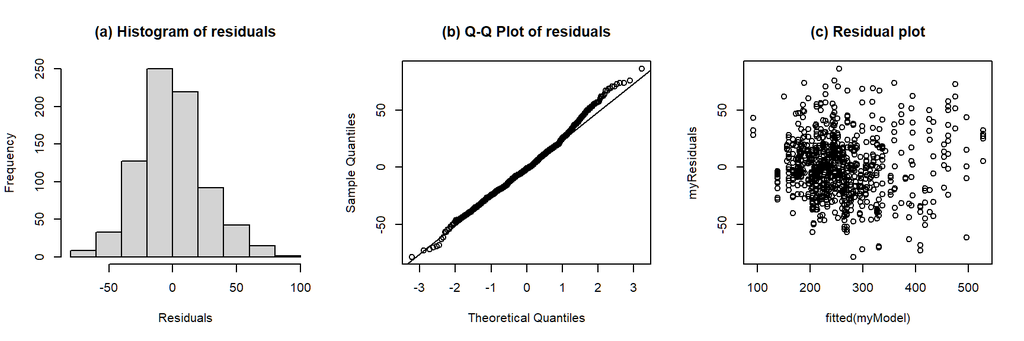

```
## Formula:  h_t ~ foot_syls + pre_syls + fin_phon + nuc_new_word + gender + (1 | speaker) + (1 | speech_rate) + (1 | nuc_str_syl)
##
## Linear mixed model fit by REML. t-tests use Satterthwaite's method [
## lmerModLmerTest]
## Formula: h_t_equation
##    Data: nuc_h_t_data.trimmed
## Control:
## lmerControl(optimizer = optimizer, calc.derivs = FALSE, optCtrl = list(method = "nlminb",
##     starttests = FALSE, kkt = FALSE))
##
## REML criterion at convergence: 7383
##
## Scaled residuals:
##     Min      1Q  Median      3Q     Max
## -2.9652 -0.6816 -0.0549  0.5891  3.2625
##
## Random effects:
##  Groups      Name        Variance  Std.Dev.
##  speech_rate (Intercept) 9.653e-04  0.03107
##  speaker     (Intercept) 5.869e+02 24.22600
##  nuc_str_syl (Intercept) 7.119e+02 26.68113
##  Residual                6.976e+02 26.41218
## Number of obs: 787, groups:  speech_rate, 635; speaker, 11; nuc_str_syl, 3
##
## Fixed effects:
##                  Estimate Std. Error      df t value Pr(>|t|)
## (Intercept)       293.154     19.362   4.642  15.141 3.96e-05 ***
## foot_syls2         21.253      4.839 765.753   4.392 1.28e-05 ***
## foot_syls3         95.924      3.835 765.845  25.014  < 2e-16 ***
## foot_syls4        217.839      6.098 767.663  35.723  < 2e-16 ***
## pre_syls1         -33.504      3.855 765.922  -8.692  < 2e-16 ***
## pre_syls2         -38.185      6.110 767.494  -6.249 6.84e-10 ***
## pre_syls3         -44.233      6.326 767.711  -6.992 5.90e-12 ***
## fin_phonL%        -45.707      5.957 769.446  -7.672 5.11e-14 ***
## nuc_new_wordTRUE  -13.416      3.730 767.415  -3.597 0.000343 ***
## genderM           -64.510     14.792   9.006  -4.361 0.001818 **
## ---
## Signif. codes:  0 '***' 0.001 '**' 0.01 '*' 0.05 '.' 0.1 ' ' 1
##
## Correlation of Fixed Effects:
```

[output cut: 24 more lines]

```
## Degrees of freedom method: Satterthwaite
##
##              Eliminated  Sum Sq Mean Sq NumDF  DenDF F value    Pr(>F)
## foot_syls             0 1207297  402432     3 766.87 576.878 < 2.2e-16 ***
## pre_syls              0   56226   18742     3 764.83  26.866 < 2.2e-16 ***
## fin_phon              0   41065   41065     1 769.45  58.866 5.112e-14 ***
## nuc_new_word          0    9026    9026     1 767.49  12.939 0.0003425 ***
## gender                0   13268   13268     1   9.01  19.019 0.0018178 **
## ---
## Signif. codes:  0 '***' 0.001 '**' 0.01 '*' 0.05 '.' 0.1 ' ' 1
##
## Model found:
## h_t ~ foot_syls + pre_syls + fin_phon + nuc_new_word + gender + (1 | speaker) + (1 | nuc_str_syl)
##
## isSingular(my_model, tol = 1e-05 ) --> FALSE
```

Anova of model: h_t ~ foot_syls + pre_syls + fin_phon + nuc_new_word + gender + (1 | speaker) + (1 | speech_rate) + (1 | nuc_str_syl)

| term | sumsq | meansq | NumDF | DenDF | F value | p.value | signif. |
| --- | --- | --- | --- | --- | --- | --- | --- |
| foot_syls | 1207295.047 | 402431.682 | 3 | 766.624 | 576.878 | 4.697225e-196 | p<0.001 |
| pre_syls | 56225.794 | 18741.931 | 3 | 764.484 | 26.866 | 1.584046e-16 | p<0.001 |
| fin_phon | 41065.129 | 41065.129 | 1 | 769.446 | 58.866 | 5.111852e-14 | p<0.001 |
| nuc_new_word | 9025.971 | 9025.971 | 1 | 767.415 | 12.939 | 3.425046e-04 | p<0.001 |
| gender | 13267.948 | 13267.948 | 1 | 9.006 | 19.019 | 1.817821e-03 | p<0.01 |

Conditional and marginal R<sup>2</sup> of model

| R2_conditional | R2_marginal |
| --- | --- |
| 0.9 | 0.7 |

$foot_syls

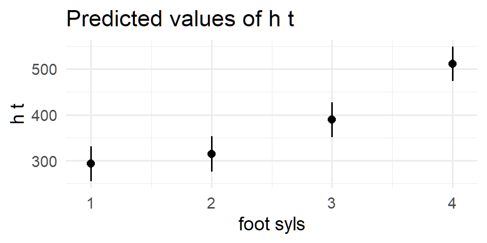

$pre_syls

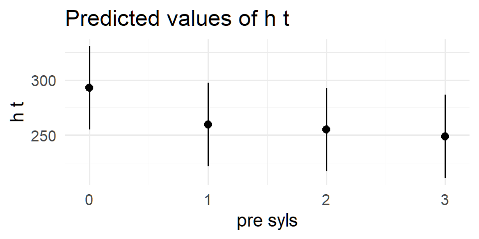

$fin_phon

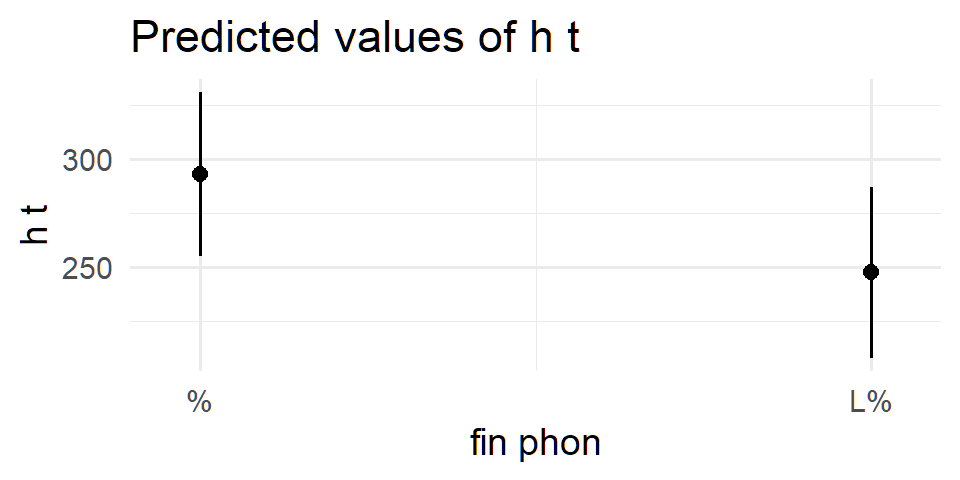

$nuc_new_word

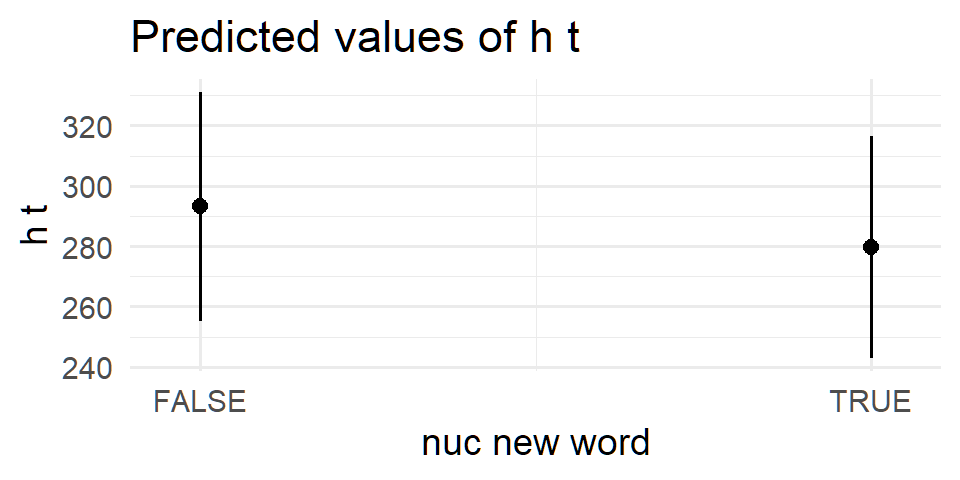

$gender

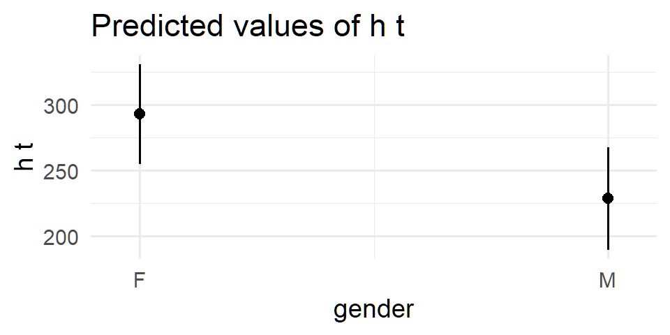

summary of model: h_t ~ foot_syls + pre_syls + fin_phon + nuc_new_word + gender + (1 | speaker) + (1 | speech_rate) + (1 | nuc_str_syl)

| term | estimate | conf.low | conf.high | std.error | t.value | df | p.value |
| --- | --- | --- | --- | --- | --- | --- | --- |
| (Intercept) | 293.154 | 242.20464 | 344.103493 | 19.362 | 15.141 | 4.64 | 4.0e-05 |
| foot_syls2 | 21.253 | 11.75333 | 30.752558 | 4.839 | 4.392 | 765.75 | 1.3e-05 |
| foot_syls3 | 95.924 | 88.39586 | 103.451550 | 3.835 | 25.014 | 765.84 | 2.1e-101 |
| foot_syls4 | 217.839 | 205.86831 | 229.809808 | 6.098 | 35.723 | 767.66 | 2.1e-165 |
| pre_syls1 | -33.504 | -41.07084 | -25.937093 | 3.855 | -8.692 | 765.92 | 2.1e-17 |
| pre_syls2 | -38.185 | -50.18076 | -26.190229 | 6.110 | -6.249 | 767.49 | 6.8e-10 |
| pre_syls3 | -44.233 | -56.65215 | -31.814186 | 6.326 | -6.992 | 767.71 | 5.9e-12 |
| fin_phonL% | -45.707 | -57.40186 | -34.012693 | 5.957 | -7.672 | 769.45 | 5.1e-14 |
| nuc_new_wordTRUE | -13.416 | -20.73790 | -6.094316 | 3.730 | -3.597 | 767.42 | 3e-04 |
| genderM | -64.510 | -97.96948 | -31.051342 | 14.792 | -4.361 | 9.01 | 0.0018 |

b0 for h_t ~ foot_syls + pre_syls + fin_phon + nuc_new_word + gender + (1 | speaker) + (1 | speech_rate) + (1 | nuc_str_syl)

| intercept | estimate | conf.low | conf.high | std.error | t.value | df | p.value |
| --- | --- | --- | --- | --- | --- | --- | --- |
| foot_syls1 | 293.1 | 242.2 | 344.1 | 19.36 | 15.14 | 4.64 | 4.0e-05 |
| foot_syls2 | 314.4 | 263.7 | 365.1 | 19.81 | 15.87 | 5.09 | 1.6e-05 |
| foot_syls3 | 389.1 | 338.1 | 440 | 19.36 | 20.10 | 4.64 | 1.1e-05 |
| foot_syls4 | 511 | 459.9 | 562.1 | 19.19 | 26.63 | 4.49 | 4.1e-06 |
| pre_syls0 | 293.1 | 242.2 | 344.1 | 19.36 | 15.14 | 4.64 | 4.0e-05 |
| pre_syls1 | 259.6 | 208.7 | 310.6 | 19.37 | 13.41 | 4.65 | 6.8e-05 |
| pre_syls2 | 255 | 204 | 305.9 | 19.35 | 13.18 | 4.64 | 7.5e-05 |
| pre_syls3 | 248.9 | 197.9 | 299.9 | 19.30 | 12.90 | 4.59 | 8.9e-05 |

b1 for h_t ~ foot_syls + pre_syls + fin_phon + nuc_new_word + gender + (1 | speaker) + (1 | speech_rate) + (1 | nuc_str_syl)

| intercept | slope | estimate | conf.low | conf.high | std.error | t.value | df | p.value |
| --- | --- | --- | --- | --- | --- | --- | --- | --- |
| foot_syls1 | foot_syls2 | 21.2 | 11.8 | 30.8 | 4.840 | 4.390 | 765.75 | 1.3e-05 |
| foot_syls1 | foot_syls3 | 95.9 | 88.4 | 103.5 | 3.830 | 25.010 | 765.84 | 2.1e-101 |
| foot_syls1 | foot_syls4 | 217.8 | 205.9 | 229.8 | 6.100 | 35.720 | 767.66 | 2.1e-165 |
| foot_syls2 | foot_syls3 | 74.7 | 64.6 | 84.8 | 5.140 | 14.520 | 765.98 | 2.2e-42 |
| foot_syls2 | foot_syls4 | 196.6 | 184.3 | 208.9 | 6.280 | 31.300 | 767.48 | 3.1e-139 |
| foot_syls3 | foot_syls4 | 121.9 | 109.5 | 134.3 | 6.330 | 19.270 | 767.68 | 8.3e-68 |
| pre_syls0 | pre_syls1 | -33.5 | -41.1 | -25.9 | 3.850 | -8.690 | 765.92 | 2.1e-17 |
| pre_syls0 | pre_syls2 | -38.2 | -50.2 | -26.2 | 6.110 | -6.250 | 767.49 | 6.8e-10 |
| pre_syls0 | pre_syls3 | -44.2 | -56.7 | -31.8 | 6.330 | -6.990 | 767.71 | 5.9e-12 |
| pre_syls1 | pre_syls2 | -4.68 | -14 | 4.62 | 4.740 | -0.990 | 767.61 | 0.323 |
| pre_syls1 | pre_syls3 | -10.7 | -20.6 | -0.902 | 5.010 | -2.140 | 766.81 | 0.032 |
| pre_syls2 | pre_syls3 | -6.05 | -13.3 | 1.249 | 3.720 | -1.630 | 753.02 | 0.104 |
| intercept | fin_phonL% | -45.7 | -57.4 | -34 | 5.957 | -7.672 | 769.45 | 5.1e-14 |
| intercept | nuc_new_wordTRUE | -13.4 | -20.7 | -6.094 | 3.730 | -3.597 | 767.43 | 3.4e-04 |
| intercept | genderM | -64.5 | -98 | -31.1 | 14.792 | -4.361 | 9.01 | 0.002 |

### Analysis of H F0

step() suggests: `h_f0 ~ foot_syls + fin_phon + (1 | speaker) + (1 | nuc_pre_text)` This is very odd. So, removing (1 | nuc_pre_text)!!

- model needs trimming (residuals +/- 4 s.d.)

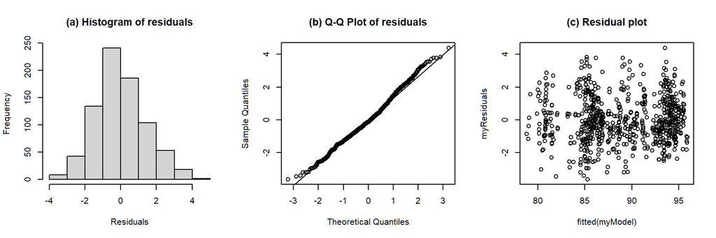

```
## Formula:  h_f0 ~ foot_syls + pre_syls + fin_phon + nuc_new_word + (1 | speaker) + (1 | speech_rate) + (1 | nuc_str_syl)
##
## Linear mixed model fit by REML. t-tests use Satterthwaite's method [
## lmerModLmerTest]
## Formula: h_f0_equation
##    Data: nuc_h_f0.trimmed
## Control:
## lmerControl(optimizer = optimizer, calc.derivs = FALSE, optCtrl = list(method = "nlminb",
##     starttests = FALSE, kkt = FALSE))
##
## REML criterion at convergence: 2948.1
##
## Scaled residuals:
##      Min       1Q   Median       3Q      Max
## -2.50753 -0.63537 -0.09025  0.60733  3.02640
##
## Random effects:
##  Groups      Name        Variance Std.Dev.
##  speech_rate (Intercept)  0.1518  0.3896
##  speaker     (Intercept) 21.0669  4.5899
##  nuc_str_syl (Intercept)  0.4149  0.6442
##  Residual                 2.0992  1.4489
## Number of obs: 787, groups:  speech_rate, 635; speaker, 11; nuc_str_syl, 3
##
## Fixed effects:
##                  Estimate Std. Error       df t value Pr(>|t|)
## (Intercept)       87.0026     1.4753  12.4744  58.972  < 2e-16 ***
## foot_syls2         0.8507     0.2765 701.7554   3.076 0.002177 **
## foot_syls3         2.2959     0.2184 717.4503  10.511  < 2e-16 ***
## foot_syls4         2.0329     0.3460 745.9976   5.875 6.37e-09 ***
## pre_syls1          0.8092     0.2199 702.6286   3.680 0.000252 ***
## pre_syls2          0.7428     0.3481 667.0648   2.134 0.033201 *
## pre_syls3          1.1368     0.3597 642.6558   3.160 0.001650 **
## fin_phonL%        -0.6195     0.3386 766.4694  -1.830 0.067666 .
## nuc_new_wordTRUE   0.4628     0.2106 657.3719   2.198 0.028301 *
## ---
## Signif. codes:  0 '***' 0.001 '**' 0.01 '*' 0.05 '.' 0.1 ' ' 1
##
## Correlation of Fixed Effects:
##             (Intr) ft_sy2 ft_sy3 ft_sy4 pr_sy1 pr_sy2 pr_sy3 fn_pL%
```

[output cut: 21 more lines]

```
## Backward reduced fixed-effect table:
## Degrees of freedom method: Satterthwaite
##
##              Eliminated  Sum Sq Mean Sq NumDF  DenDF F value    Pr(>F)
## fin_phon              1   7.539   7.539     1 766.49  3.3507 0.0675637 .
## foot_syls             0 273.351  91.117     3 767.46 40.3744 < 2.2e-16 ***
## pre_syls              0  38.787  12.929     3 613.97  5.7290 0.0007187 ***
## nuc_new_word          0   9.515   9.515     1 672.86  4.2163 0.0404225 *
## ---
## Signif. codes:  0 '***' 0.001 '**' 0.01 '*' 0.05 '.' 0.1 ' ' 1
##
## Model found:
## h_f0 ~ foot_syls + pre_syls + nuc_new_word + (1 | speaker) + (1 | nuc_str_syl)
##
## isSingular(my_model, tol = 1e-05 ) --> FALSE
```

Anova of model: h_f0 ~ foot_syls + pre_syls + fin_phon + nuc_new_word + (1 | speaker) + (1 | speech_rate) + (1 | nuc_str_syl)

| term | sumsq | meansq | NumDF | DenDF | F value | p.value | signif. |
| --- | --- | --- | --- | --- | --- | --- | --- |
| foot_syls | 257.993 | 85.998 | 3 | 722.341 | 40.967 | 1.864337e-24 | p<0.001 |
| pre_syls | 36.137 | 12.046 | 3 | 558.854 | 5.738 | 7.167826e-04 | p<0.001 |
| fin_phon | 7.029 | 7.029 | 1 | 766.469 | 3.348 | 6.766558e-02 |  |
| nuc_new_word | 10.141 | 10.141 | 1 | 657.372 | 4.831 | 2.830096e-02 | p<0.05 |

Conditional and marginal R<sup>2</sup> of model

| R2_conditional | R2_marginal |
| --- | --- |
| 0.91 | 0.02 |

$foot_syls

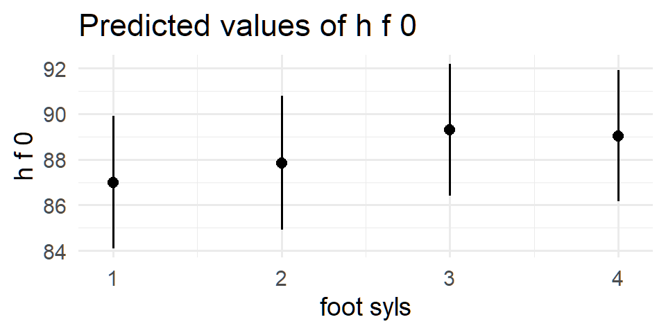

$pre_syls

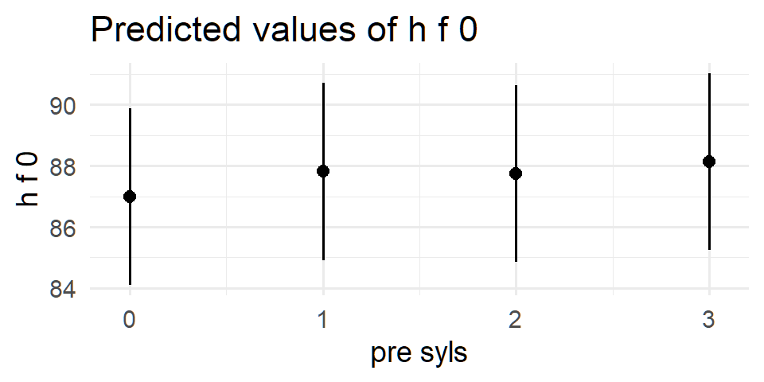

$fin_phon

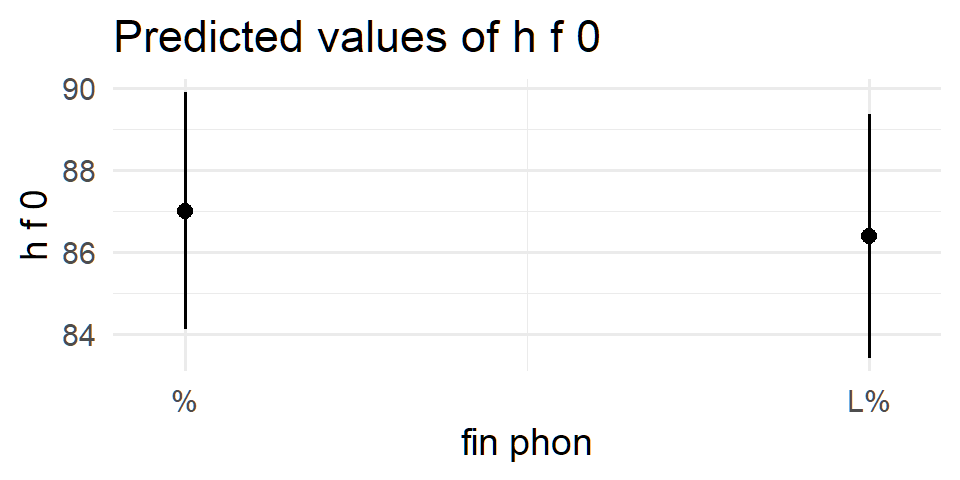

$nuc_new_word

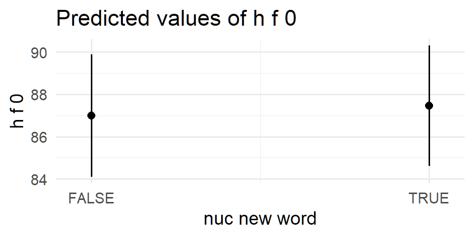

summary of model: h_f0 ~ foot_syls + pre_syls + fin_phon + nuc_new_word + (1 | speaker) + (1 | speech_rate) + (1 | nuc_str_syl)

| term | estimate | conf.low | conf.high | std.error | t.value | df | p.value |
| --- | --- | --- | --- | --- | --- | --- | --- |
| (Intercept) | 87.003 | 83.80165869 | 90.20349882 | 1.475 | 58.972 | 12.47 | 1.2e-16 |
| foot_syls2 | 0.851 | 0.30776345 | 1.39359102 | 0.277 | 3.076 | 701.76 | 0.0022 |
| foot_syls3 | 2.296 | 1.86709356 | 2.72474381 | 0.218 | 10.511 | 717.45 | 3.9e-24 |
| foot_syls4 | 2.033 | 1.35359978 | 2.71220692 | 0.346 | 5.875 | 746.00 | 6.4e-09 |
| pre_syls1 | 0.809 | 0.37741926 | 1.24095847 | 0.220 | 3.680 | 702.63 | 3e-04 |
| pre_syls2 | 0.743 | 0.05935877 | 1.42620553 | 0.348 | 2.134 | 667.06 | 0.0332 |
| pre_syls3 | 1.137 | 0.43043723 | 1.84316252 | 0.360 | 3.160 | 642.66 | 0.0017 |
| fin_phonL% | -0.619 | -1.28409372 | 0.04511124 | 0.339 | -1.830 | 766.47 | 0.0677 |
| nuc_new_wordTRUE | 0.463 | 0.04934988 | 0.87628305 | 0.211 | 2.198 | 657.37 | 0.0283 |

b0 for h_f0 ~ foot_syls + pre_syls + fin_phon + nuc_new_word + (1 | speaker) + (1 | speech_rate) + (1 | nuc_str_syl)

| intercept | estimate | conf.low | conf.high | std.error | t.value | df | p.value |
| --- | --- | --- | --- | --- | --- | --- | --- |
| foot_syls1 | 87 | 83.8 | 90.2 | 1.48 | 58.97 | 12.47 | 1.2e-16 |
| foot_syls2 | 87.8 | 84.6 | 91.1 | 1.49 | 58.78 | 13.14 | 2.7e-17 |
| foot_syls3 | 89.3 | 86.1 | 92.5 | 1.48 | 60.53 | 12.47 | 8.9e-17 |
| foot_syls4 | 89 | 85.8 | 92.2 | 1.47 | 60.62 | 12.26 | 1.4e-16 |
| pre_syls0 | 87 | 83.8 | 90.2 | 1.48 | 58.97 | 12.47 | 1.2e-16 |
| pre_syls1 | 87.8 | 84.6 | 91 | 1.48 | 59.50 | 12.49 | 1.0e-16 |
| pre_syls2 | 87.8 | 84.5 | 90.9 | 1.48 | 59.46 | 12.50 | 1.0e-16 |
| pre_syls3 | 88.1 | 84.9 | 91.3 | 1.47 | 59.79 | 12.45 | 1.1e-16 |

b1 for h_f0 ~ foot_syls + pre_syls + fin_phon + nuc_new_word + (1 | speaker) + (1 | speech_rate) + (1 | nuc_str_syl)

| intercept | slope | estimate | conf.low | conf.high | std.error | t.value | df | p.value |
| --- | --- | --- | --- | --- | --- | --- | --- | --- |
| foot_syls1 | foot_syls2 | 0.85 | 0.308 | 1.394 | 0.280 | 3.080 | 701.76 | 0.002 |
| foot_syls1 | foot_syls3 | 2.3 | 1.867 | 2.725 | 0.220 | 10.510 | 717.45 | 3.9e-24 |
| foot_syls1 | foot_syls4 | 2.03 | 1.354 | 2.712 | 0.350 | 5.870 | 746.00 | 6.4e-09 |
| foot_syls2 | foot_syls3 | 1.45 | 0.868 | 2.022 | 0.290 | 4.920 | 693.30 | 1.1e-06 |
| foot_syls2 | foot_syls4 | 1.18 | 0.48 | 1.884 | 0.360 | 3.310 | 708.09 | 1.0e-03 |
| foot_syls3 | foot_syls4 | -0.26 | -0.967 | 0.441 | 0.360 | -0.730 | 756.42 | 0.464 |
| pre_syls0 | pre_syls1 | 0.81 | 0.377 | 1.241 | 0.220 | 3.680 | 702.63 | 2.5e-04 |
| pre_syls0 | pre_syls2 | 0.74 | 0.059 | 1.426 | 0.350 | 2.130 | 667.06 | 0.033 |
| pre_syls0 | pre_syls3 | 1.14 | 0.43 | 1.843 | 0.360 | 3.160 | 642.66 | 0.002 |
| pre_syls1 | pre_syls2 | -0.07 | -0.596 | 0.463 | 0.270 | -0.250 | 608.20 | 0.806 |
| pre_syls1 | pre_syls3 | 0.33 | -0.23 | 0.885 | 0.280 | 1.150 | 582.49 | 0.249 |
| pre_syls2 | pre_syls3 | 0.39 | -0.014 | 0.802 | 0.210 | 1.900 | 382.33 | 0.058 |
| intercept | fin_phonL% | -0.619 | -1.284 | 0.045 | 0.339 | -1.830 | 766.47 | 0.068 |
| intercept | nuc_new_wordTRUE | 0.463 | 0.049 | 0.876 | 0.211 | 2.198 | 657.37 | 0.028 |

## E targets

### Analysis of E timing

NB, E timing is not of interest!

initial step() suggests:

`e_t ~ foot_syls + pre_syls + gender + (1 | speaker) + (1 | nuc_str_syl)`

- intercepts only model
- model needs trimming

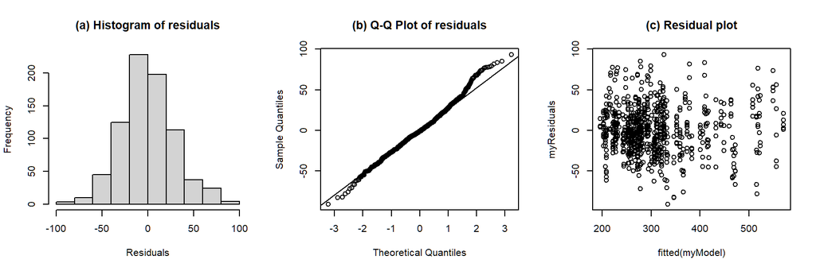

```
## Formula:  e_t ~ foot_syls + pre_syls + fin_phon + nuc_new_word + gender + (1 | speaker) + (1 | speech_rate) + (1 | nuc_str_syl)
##
## Linear mixed model fit by REML. t-tests use Satterthwaite's method [
## lmerModLmerTest]
## Formula: e_t_equation
##    Data: nuc_e_t.trimmed
## Control:
## lmerControl(optimizer = optimizer, calc.derivs = FALSE, optCtrl = list(method = "nlminb",
##     starttests = FALSE, kkt = FALSE))
##
## REML criterion at convergence: 7539.7
##
## Scaled residuals:
##     Min      1Q  Median      3Q     Max
## -3.1237 -0.6307 -0.0471  0.5892  3.1918
##
## Random effects:
##  Groups      Name        Variance  Std.Dev.
##  speech_rate (Intercept) 4.771e-05  0.006907
##  speaker     (Intercept) 6.991e+02 26.439577
##  nuc_str_syl (Intercept) 1.040e+03 32.246146
##  Residual                8.534e+02 29.213267
## Number of obs: 787, groups:  speech_rate, 635; speaker, 11; nuc_str_syl, 3
##
## Fixed effects:
##                  Estimate Std. Error      df t value Pr(>|t|)
## (Intercept)       330.004     22.624   4.135  14.586 0.000103 ***
## foot_syls2         11.413      5.355 766.108   2.131 0.033373 *
## foot_syls3        117.127      4.247 766.110  27.582  < 2e-16 ***
## foot_syls4        248.909      6.747 767.541  36.894  < 2e-16 ***
## pre_syls1         -31.242      4.273 766.237  -7.312 6.65e-13 ***
## pre_syls2         -31.399      6.766 767.775  -4.641 4.08e-06 ***
## pre_syls3         -36.048      7.006 768.183  -5.146 3.39e-07 ***
## fin_phonL%         -6.716      6.589 769.520  -1.019 0.308423
## nuc_new_wordTRUE   -5.961      4.127 767.913  -1.445 0.148996
## genderM           -47.861     16.147   9.000  -2.964 0.015857 *
## ---
## Signif. codes:  0 '***' 0.001 '**' 0.01 '*' 0.05 '.' 0.1 ' ' 1
##
## Correlation of Fixed Effects:
```

[output cut: 24 more lines]

```
## Degrees of freedom method: Satterthwaite
##
##              Eliminated  Sum Sq Mean Sq NumDF  DenDF   F value    Pr(>F)
## fin_phon              1     887     887     1 769.52    1.0388   0.30842
## nuc_new_word          2    1850    1850     1 768.90    2.1679   0.14133
## foot_syls             0 2634182  878061     3 768.09 1027.1815 < 2.2e-16 ***
## pre_syls              0   46937   15646     3 769.01   18.3030  1.77e-11 ***
## gender                0    7512    7512     1   9.00    8.7872   0.01585 *
## ---
## Signif. codes:  0 '***' 0.001 '**' 0.01 '*' 0.05 '.' 0.1 ' ' 1
##
## Model found:
## e_t ~ foot_syls + pre_syls + gender + (1 | speaker) + (1 | nuc_str_syl)
##
## isSingular(my_model, tol = 1e-05 ) --> FALSE
```

Anova of model: e_t ~ foot_syls + pre_syls + fin_phon + nuc_new_word + gender + (1 | speaker) + (1 | speech_rate) + (1 | nuc_str_syl)

| term | sumsq | meansq | NumDF | DenDF | F value | p.value | signif. |
| --- | --- | --- | --- | --- | --- | --- | --- |
| foot_syls | 1715688.087 | 571896.029 | 3 | 766.766 | 670.127 | 9.733983e-214 | p<0.001 |
| pre_syls | 46809.297 | 15603.099 | 3 | 766.064 | 18.283 | 1.825151e-11 | p<0.001 |
| fin_phon | 886.522 | 886.522 | 1 | 769.520 | 1.039 | 3.084225e-01 |  |
| nuc_new_word | 1780.811 | 1780.811 | 1 | 767.913 | 2.087 | 1.489958e-01 |  |
| gender | 7497.502 | 7497.502 | 1 | 9.000 | 8.785 | 1.585669e-02 | p<0.05 |

Conditional and marginal R<sup>2</sup> of model

| R2_conditional | R2_marginal |
| --- | --- |
| 0.9 | 0.68 |

$foot_syls

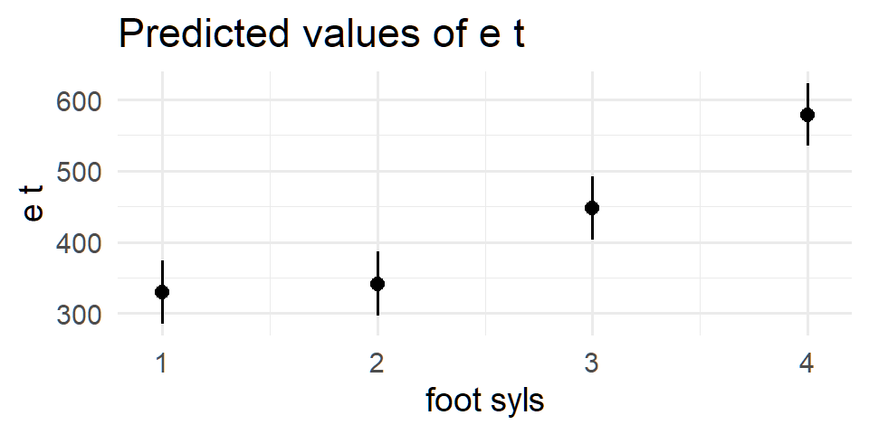

$pre_syls

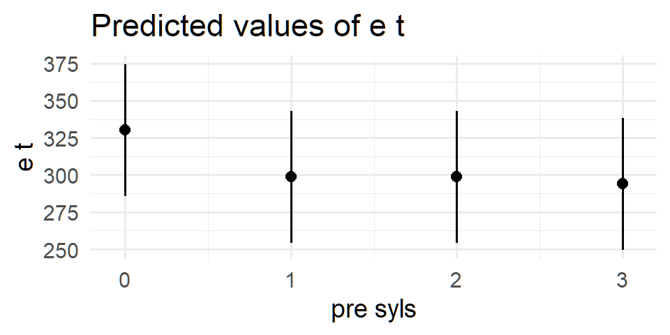

$fin_phon

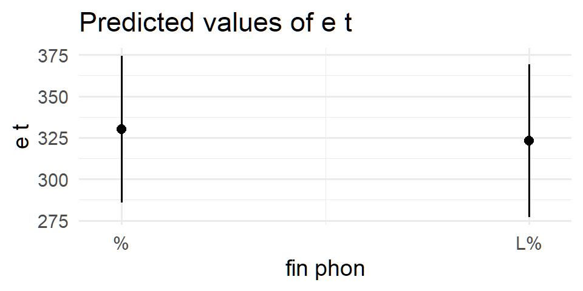

$nuc_new_word

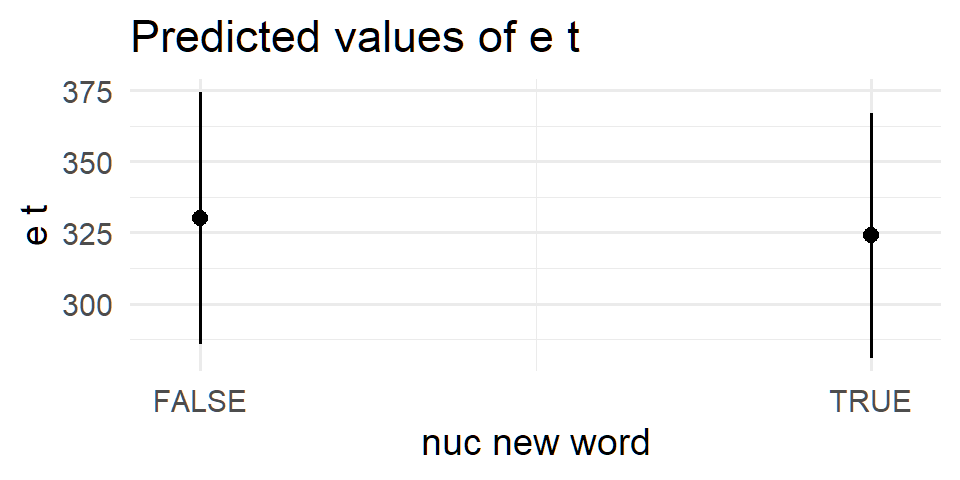

$gender

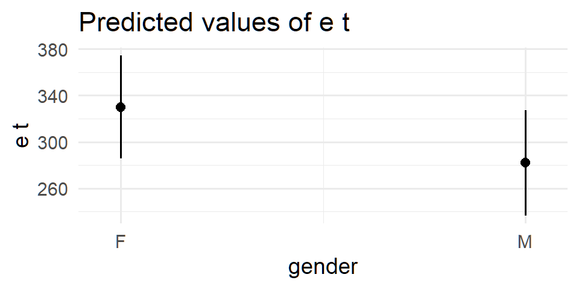

summary of model: e_t ~ foot_syls + pre_syls + fin_phon + nuc_new_word + gender + (1 | speaker) + (1 | speech_rate) + (1 | nuc_str_syl)

| term | estimate | conf.low | conf.high | std.error | t.value | df | p.value |
| --- | --- | --- | --- | --- | --- | --- | --- |
| (Intercept) | 330.004 | 267.9918893 | 392.015734 | 22.624 | 14.586 | 4.14 | 1e-04 |
| foot_syls2 | 11.413 | 0.9013842 | 21.923890 | 5.355 | 2.131 | 766.11 | 0.0334 |
| foot_syls3 | 117.127 | 108.7907504 | 125.463068 | 4.247 | 27.582 | 766.11 | 7.6e-117 |
| foot_syls4 | 248.909 | 235.6645867 | 262.152837 | 6.747 | 36.894 | 767.54 | 3.5e-172 |
| pre_syls1 | -31.242 | -39.6300428 | -22.854306 | 4.273 | -7.312 | 766.24 | 6.6e-13 |
| pre_syls2 | -31.399 | -44.6811993 | -18.117779 | 6.766 | -4.641 | 767.78 | 4.1e-06 |
| pre_syls3 | -36.048 | -49.8008604 | -22.295639 | 7.006 | -5.146 | 768.18 | 3.4e-07 |
| fin_phonL% | -6.716 | -19.6508788 | 6.219192 | 6.589 | -1.019 | 769.52 | 0.3084 |
| nuc_new_wordTRUE | -5.961 | -14.0620798 | 2.139773 | 4.127 | -1.445 | 767.91 | 0.149 |
| genderM | -47.861 | -84.3892467 | -11.332796 | 16.147 | -2.964 | 9.00 | 0.0159 |

b0 for e_t ~ foot_syls + pre_syls + fin_phon + nuc_new_word + gender + (1 | speaker) + (1 | speech_rate) + (1 | nuc_str_syl)

| intercept | estimate | conf.low | conf.high | std.error | t.value | df | p.value |
| --- | --- | --- | --- | --- | --- | --- | --- |
| foot_syls1 | 330 | 268 | 392 | 22.62 | 14.59 | 4.14 | 1.0e-04 |
| foot_syls2 | 341.4 | 280 | 402.9 | 23.10 | 14.78 | 4.49 | 5.6e-05 |
| foot_syls3 | 447.1 | 385.1 | 509.1 | 22.62 | 19.77 | 4.13 | 3.0e-05 |
| foot_syls4 | 578.9 | 516.7 | 641.2 | 22.45 | 25.79 | 4.01 | 1.3e-05 |
| pre_syls0 | 330 | 268 | 392 | 22.62 | 14.59 | 4.14 | 1.0e-04 |
| pre_syls1 | 298.8 | 236.8 | 360.8 | 22.63 | 13.20 | 4.14 | 1.5e-04 |
| pre_syls2 | 298.6 | 236.6 | 360.6 | 22.61 | 13.21 | 4.13 | 1.6e-04 |
| pre_syls3 | 294 | 231.9 | 356 | 22.56 | 13.03 | 4.09 | 1.7e-04 |

b1 for e_t ~ foot_syls + pre_syls + fin_phon + nuc_new_word + gender + (1 | speaker) + (1 | speech_rate) + (1 | nuc_str_syl)

| intercept | slope | estimate | conf.low | conf.high | std.error | t.value | df | p.value |
| --- | --- | --- | --- | --- | --- | --- | --- | --- |
| foot_syls1 | foot_syls2 | 11.4 | 0.901 | 21.9 | 5.350 | 2.130 | 766.11 | 0.033 |
| foot_syls1 | foot_syls3 | 117.1 | 108.8 | 125.5 | 4.250 | 27.580 | 766.11 | 7.6e-117 |
| foot_syls1 | foot_syls4 | 248.9 | 235.7 | 262.2 | 6.750 | 36.890 | 767.54 | 3.5e-172 |
| foot_syls2 | foot_syls3 | 105.7 | 94.5 | 116.9 | 5.710 | 18.510 | 766.25 | 1.7e-63 |
| foot_syls2 | foot_syls4 | 237.5 | 223.9 | 251.1 | 6.950 | 34.180 | 767.46 | 2.4e-156 |
| foot_syls3 | foot_syls4 | 131.8 | 118 | 145.6 | 7.020 | 18.780 | 767.51 | 4.8e-65 |
| pre_syls0 | pre_syls1 | -31.2 | -39.6 | -22.9 | 4.270 | -7.310 | 766.24 | 6.6e-13 |
| pre_syls0 | pre_syls2 | -31.4 | -44.7 | -18.1 | 6.770 | -4.640 | 767.78 | 4.1e-06 |
| pre_syls0 | pre_syls3 | -36 | -49.8 | -22.3 | 7.010 | -5.150 | 768.18 | 3.4e-07 |
| pre_syls1 | pre_syls2 | -0.16 | -10.4 | 10.1 | 5.240 | -0.030 | 768.01 | 0.976 |
| pre_syls1 | pre_syls3 | -4.81 | -15.7 | 6.067 | 5.540 | -0.870 | 767.74 | 0.386 |
| pre_syls2 | pre_syls3 | -4.65 | -12.7 | 3.428 | 4.110 | -1.130 | 758.91 | 0.259 |
| intercept | fin_phonL% | -6.716 | -19.7 | 6.219 | 6.589 | -1.019 | 769.52 | 0.308 |
| intercept | nuc_new_wordTRUE | -5.961 | -14.1 | 2.14 | 4.127 | -1.445 | 767.91 | 0.149 |
| intercept | genderM | -47.9 | -84.4 | -11.3 | 16.147 | -2.964 | 9.00 | 0.016 |